# Decision Tree Classifier for Beginners in R

Gian Carlo Sanfuego

2024-07-25

The Decision Tree algorithm is a member of the family of supervised machine learning algorithms. These algorithms typically rely on the concept of ground truth, which involves actual labels indicating, for instance, whether a person has diabetes or not. By comparing the model’s predictions with these ground truth labels, metrics can be generated to evaluate the model’s performance. Essentially, this underlines that Decision Tree is a supervised learning algorithm.

Decision Trees can be utilized for both classification and regression tasks. In a supervised learning context, the problem can be either classification or regression, and Decision Trees are capable of handling both. The primary objective of the Decision Tree algorithm is to develop a model that predicts the value of a target variable 𝑦 y. The algorithm uses a tree structure to solve the problem, where the leaf nodes represent class labels, and the internal nodes represent attributes.

For a more comprehensive understanding, please refer to the illustration below.

## Task One: Getting Started

In this task, you will get started by getting an overview of the project

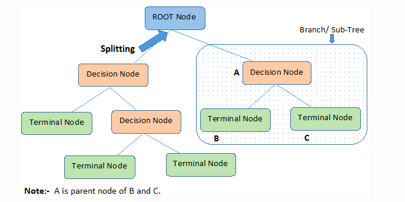

Decision Tree Representation

The Decision Tree algorithm is a powerful tool within the realm of supervised machine learning, known for its ability to handle both classification and regression tasks. A Decision Tree is structured with several key components: the root node, decision nodes (also called internal nodes), and terminal nodes (or leaf nodes).

As depicted in the diagram, the root node represents the initial decision point, from which the dataset is split based on certain criteria. Decision nodes represent further splits within the tree, while terminal nodes indicate the final outcomes or class labels.

The algorithm selects splits based on the principle of creating the most homogeneous partitions, meaning it aims to group similar instances together. This process involves iteratively dividing the dataset into smaller, more homogeneous subsets. Each split is based on one of the input variables, and the goal is to maximize the homogeneity within each resulting partition.

Starting from the root node, the tree grows by evaluating the homogeneity of the outcome within each group and continuing to split as necessary. This process continues until the groups are sufficiently homogeneous or cannot be split further without reducing their similarity.

One of the significant advantages of Decision Trees is their interpretability. They simplify complex decision-making processes by breaking them down into a series of straightforward, smaller decisions, following a divide-and-conquer strategy. The tree structure effectively represents a set of if-else conditions that split the data based on the values of the variables.

Additionally, Decision Trees often perform better than linear regression in non-linear settings due to their ability to capture non-linear relationships between variables. However, a major drawback is the potential for overfitting, especially if the tree grows too large without pruning or cross-validation. Pruning and cross-validation techniques are essential to mitigate overfitting and ensure the model generalizes well to new data.

## Task Two: Import Required Libraries

In this task, you will learn how to import the required packages for this project

```r
## 2.1: Import the required packages
#install.packages("tree")
#install.packages("caret")
#install.packages("rpart")
#install.packages("rpart.plot")
#install.packages("mlbench")
#install.packages("e1071")
library(tree)
library(caret)
library(rpart)
library(rpart.plot)
library(mlbench)
library(e1071)
```

The ‘mlbench’ package is a collection of benchmark data sets and functions for machine learning in R. We will use a sonar data set in that package. To load the data we will use the data function and put the name of the data set in quotes. First thing to always do is to now what this data really contain. You can use the ?sonar to review the details and understand what is in Sonar data.

Description of Sonar Data “This is the data set used by Gorman and Sejnowski in their study of the classification of sonar signals using a neural network [1]. The task is to train a network to discriminate between sonar signals bounced off a metal cylinder and those bounced off a roughly cylindrical rock.”

## Task Three: Import and Explore Dataset

In this task, you will learn how to import and explore the data set

```r
## 3.1: Load the dataset in R
data("Sonar")
```

Let’s now proceed the our exploration of data. One thing we can do quickly is to use the View() function to open up a new tab consists of all variables of the data.

```r
## 3.2: View the dataset
View(Sonar)
```

As you can see, we have a table consist of 61 variables and 208 values. It says that each pattern is a set of 60 numbers in the range 0.0 to 1.0. Each number represents the energy within a particular frequency. And if you scroll to the last part, you can see the class label. The only, nominal column, namely Class with values M and R. Now let’s try to obtain the frequency of the target variable or the Class column for us to be sure that our data set labels are balanced. That is one thing you should always do when you talk about a machine learning task, because if the labels are not balanced, your model that you would train will learn more of the one value, example if the M has 60 counts and 20 for R, the model will learn more of the M than of R. Unless we try to do some of the different tools for balancing the Class.

```r
## 3.3: Obtain the frequency of the target variable
table(Sonar$Class)
```

```
##
##   M   R
## 111  97
```

As you can we, we have 111 for M and 97 for R. Which is quite close. Though it is not equal, it is still quite balance unlike if we have let’s say 111 and 50. So this is still kind of balanced. So we can actually proceed and build classification model. But before that, let’s first check for missing values. We can use this function sum then is.na which says is there any missing value in this Sonar data?

```r
## 3.4: Check for missing values
sum(is.na(Sonar))
```

```
## [1] 0
```

Ans this shows us that the result is zero, meaning we have no missing values. Alternatively, we can use the anyNA() function to check for missing values.

```r
## OR
anyNA(Sonar)
```

```
## [1] FALSE
```

And it shows, FALSE, meaning there is no any single missing values in our data set. Let’s proceed with our exploration, another thing we want to do is to check the summary of the data, there is this summary() function in R that helps with getting this summary of the data.

```r
## 3.5: Summarise the data set
summary(Sonar)
```

```
##        V1                V2                V3                V4
##  Min.   :0.00150   Min.   :0.00060   Min.   :0.00150   Min.   :0.00580
##  1st Qu.:0.01335   1st Qu.:0.01645   1st Qu.:0.01895   1st Qu.:0.02438
##  Median :0.02280   Median :0.03080   Median :0.03430   Median :0.04405
##  Mean   :0.02916   Mean   :0.03844   Mean   :0.04383   Mean   :0.05389
##  3rd Qu.:0.03555   3rd Qu.:0.04795   3rd Qu.:0.05795   3rd Qu.:0.06450
##  Max.   :0.13710   Max.   :0.23390   Max.   :0.30590   Max.   :0.42640
##        V5                V6                V7               V8
##  Min.   :0.00670   Min.   :0.01020   Min.   :0.0033   Min.   :0.00550
##  1st Qu.:0.03805   1st Qu.:0.06703   1st Qu.:0.0809   1st Qu.:0.08042
##  Median :0.06250   Median :0.09215   Median :0.1070   Median :0.11210
##  Mean   :0.07520   Mean   :0.10457   Mean   :0.1217   Mean   :0.13480
##  3rd Qu.:0.10028   3rd Qu.:0.13412   3rd Qu.:0.1540   3rd Qu.:0.16960
##  Max.   :0.40100   Max.   :0.38230   Max.   :0.3729   Max.   :0.45900
##        V9               V10              V11              V12
##  Min.   :0.00750   Min.   :0.0113   Min.   :0.0289   Min.   :0.0236
##  1st Qu.:0.09703   1st Qu.:0.1113   1st Qu.:0.1293   1st Qu.:0.1335
##  Median :0.15225   Median :0.1824   Median :0.2248   Median :0.2490
##  Mean   :0.17800   Mean   :0.2083   Mean   :0.2360   Mean   :0.2502
##  3rd Qu.:0.23342   3rd Qu.:0.2687   3rd Qu.:0.3016   3rd Qu.:0.3312
##  Max.   :0.68280   Max.   :0.7106   Max.   :0.7342   Max.   :0.7060
##       V13              V14              V15              V16
##  Min.   :0.0184   Min.   :0.0273   Min.   :0.0031   Min.   :0.0162
##  1st Qu.:0.1661   1st Qu.:0.1752   1st Qu.:0.1646   1st Qu.:0.1963
##  Median :0.2640   Median :0.2811   Median :0.2817   Median :0.3047
##  Mean   :0.2733   Mean   :0.2966   Mean   :0.3202   Mean   :0.3785
##  3rd Qu.:0.3513   3rd Qu.:0.3862   3rd Qu.:0.4529   3rd Qu.:0.5357
##  Max.   :0.7131   Max.   :0.9970   Max.   :1.0000   Max.   :0.9988
##       V17              V18              V19              V20
##  Min.   :0.0349   Min.   :0.0375   Min.   :0.0494   Min.   :0.0656
##  1st Qu.:0.2059   1st Qu.:0.2421   1st Qu.:0.2991   1st Qu.:0.3506
##  Median :0.3084   Median :0.3683   Median :0.4350   Median :0.5425
##  Mean   :0.4160   Mean   :0.4523   Mean   :0.5048   Mean   :0.5630
##  3rd Qu.:0.6594   3rd Qu.:0.6791   3rd Qu.:0.7314   3rd Qu.:0.8093
##  Max.   :1.0000   Max.   :1.0000   Max.   :1.0000   Max.   :1.0000
##       V21              V22              V23              V24
##  Min.   :0.0512   Min.   :0.0219   Min.   :0.0563   Min.   :0.0239
##  1st Qu.:0.3997   1st Qu.:0.4069   1st Qu.:0.4502   1st Qu.:0.5407
##  Median :0.6177   Median :0.6649   Median :0.6997   Median :0.6985
##  Mean   :0.6091   Mean   :0.6243   Mean   :0.6470   Mean   :0.6727
```

[output cut: 57 more lines]

```
##  Max.   :0.039000   Max.   :0.035200   Max.   :0.04470   Max.   :0.039400
##       V57               V58                V59                V60
##  Min.   :0.00030   Min.   :0.000300   Min.   :0.000100   Min.   :0.000600
##  1st Qu.:0.00370   1st Qu.:0.003600   1st Qu.:0.003675   1st Qu.:0.003100
##  Median :0.00595   Median :0.005800   Median :0.006400   Median :0.005300
##  Mean   :0.00782   Mean   :0.007949   Mean   :0.007941   Mean   :0.006507
##  3rd Qu.:0.01043   3rd Qu.:0.010350   3rd Qu.:0.010325   3rd Qu.:0.008525
##  Max.   :0.03550   Max.   :0.044000   Max.   :0.036400   Max.   :0.043900
##  Class
##  M:111
##  R: 97
##
##
##
##
```

This shows us all the five number summary of all the variables 1 to 60 with the mean values. With minimum, 1st quartile, median, 3rd quartile, and maximum. While for categorical variables, it gives us the frequency of the variable.

```r
## Exercise 3.1: Check the number of rows and columns
nrow(Sonar)
```

```
## [1] 208
```

```r
ncol(Sonar)
```

```
## [1] 61
```

We have 208 number of rows and 61 columns. Now the next thing we want to do, is to do a visualization to have an idea of the data and i will randomly select 9 variables only because we have 60 variables, and that is too many. I will set seet to help this project be reproducible. So what ever answer i get now, you’ll get that too if you try to reproduce this.

```r
## Set seed to 11
set.seed(11)
```

Now what we want to do is to randomly select nine features that we will plot using box plot. To do that, let’s create a variable column and sample 9 from 60 variables using the sample() function with two parameters, the x which is the whole data and the size of 9. Then next is we will now create a new variable which contains the 9 column-subset of data.

```r
## 3.6: Randomly choose nine features from the data set
columns <- sample(x = 1:60, size = 9)
columns
```

```
## [1] 58 34 56 25 16 49 37 12 21
```

```r
pre_var <- Sonar[, columns]
pre_var
```

```
##        V58    V34    V56    V25    V16    V49    V37    V12    V21
## 1   0.0084 0.7547 0.0167 0.6711 0.2273 0.0383 0.6692 0.1582 0.5783
## 2   0.0049 0.2341 0.0191 0.3250 0.9444 0.0409 0.3835 0.6552 0.5212
## 3   0.0164 0.2709 0.0244 0.5331 0.6931 0.0130 0.6116 0.7060 0.7974
## 4   0.0044 0.3497 0.0073 0.3140 0.2131 0.0681 0.5408 0.1992 0.2741
## 5   0.0048 0.0981 0.0015 0.3161 0.5326 0.0230 0.4604 0.3952 0.4148
## 6   0.0027 0.2198 0.0089 0.2043 0.9988 0.0264 0.3807 0.4250 0.2074
## 7   0.0143 0.1873 0.0138 0.5268 0.5440 0.0507 0.6153 0.0658 0.7723
## 8   0.0047 0.4006 0.0097 0.7613 0.4376 0.0285 0.1915 0.3086 0.7832
## 9   0.0093 0.3305 0.0049 0.3374 0.1136 0.0777 0.2463 0.1654 0.9802
## 10  0.0035 0.0306 0.0068 0.9207 0.1133 0.0092 0.1594 0.1056 0.6068
## 11  0.0003 0.6055 0.0093 0.6654 0.0907 0.0228 0.3947 0.0996 0.1847
## 12  0.0092 0.2641 0.0118 0.5973 0.2032 0.0134 0.3994 0.0847 0.7852
## 13  0.0058 0.2351 0.0019 0.6833 0.2723 0.0152 0.3382 0.1215 0.9674
## 14  0.0053 0.3601 0.0152 0.6009 0.5326 0.0146 0.3858 0.2547 0.3542
```

[output cut: 194 more lines]

As you can see, this results in values of the columns we extract from the data. Since we have 9 columns selected that we will visualize we have 9 spaced to put our visuals of the distributions. We will going to use the par() function, this produces a number of plots we want to show. Lastly, is the boxplot of the selected 9 columns. I’ve written a simple functions that shows the boxplots of each of the 9 columns and plot it in a 3x3.

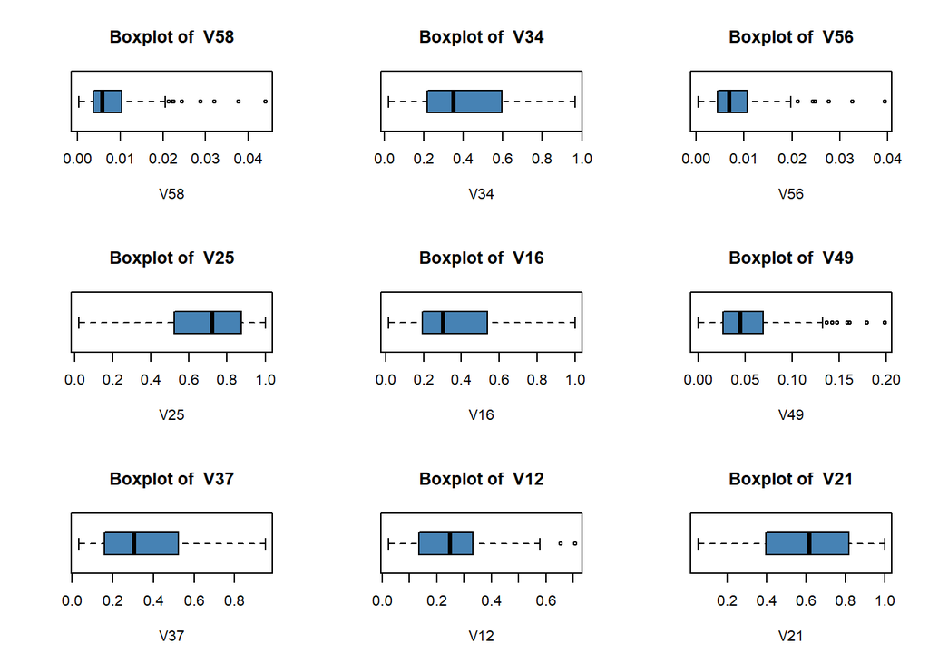

```r
par(mfrow = c(3,3))   # This produces a 3 by 3 plot of the box plots
## 3.7: Show box plots of the predictor variables
for (i in 1:ncol(pre_var)){
  boxplot(pre_var[, i], xlab = names(pre_var[i]),
       main = paste("Boxplot of ",names(pre_var[i])),
       horizontal = TRUE, col = "steelblue")
}
```

We can now see that there are some outliers in some variables, some of the variables are quite normally distributed, while some are quite skewed to the right and some are skewed to the left. And in V12, V49, V56, and V58, we can see that there’s an outliers. This gives us an idea of what our variables mean.

## Task Four: Create Train and Test Sets

In this task, you will learn how to create the train and test data sets to build the decision tree model

In machine learning, generally, the common task is to build algorithm that can learn and make predictions from data. Such algorithms function by making data driven predictions or decisions through building a mathematical model from the input data. So the idea of the train and test set is that the train set is a subset of the data used to train the model, while the test set is a subset of the data used to test the trained model. Generally, the training data set are samples used to create the model, while the test or the validation set is used to qualify the performance of the model. Traditionally, the data set used to evaluate the final model’s performance is called the test set. Usually, the goal of machine learning is that we want to build a model that can generalize on real life data. Not just something that can learn only and give accuracy just while we are building the model. So we want to split the whole data set into two different data, the train data and the test data. Let’s now create a partition of our data. To do that lets create new variable index with createDataPartition() function.

```r
## 4.1: Set Random Seed to 42
set.seed(42)
## 4.2: Partition the dataset in the ratio 70:30
index <- createDataPartition(y=Sonar$Class, p=0.7, list=FALSE)
```

What it does is it creates a partition of data set which consists of 70 percent of the data and another 30 percent of the data. The arguments in the function includes the y which is the variable class, p which is the percentage of the data that will go to the training set, and list FALSE so it does not return a list. Let’s now create a new variable for training and test sets.

```r
## 4.3: Create a training dataset for indexes
train_set <- Sonar[index,]
```

Since the index variable has 70 percent of the data, we will inserted it inside the train_set variable, then for the other 30, it will be in the test_set. Just use the negative of the index.

```r
## 4.4: Create a testing dataset for indexes
test_set <- Sonar[-index,]
```

To check for the dimension, we will just use the dim() function and use the train and test_set as argument.

```r
## Exercise 4.1: Check the dimensions of the train and test sets
dim(train_set)
```

```
## [1] 146  61
```

```r
dim(test_set)
```

```
## [1] 62 61
```

All set, we have 146 rows and 61 columns in train_set, and we have 62 rows and 61 columns for test_set.

## Task Five: Train the Decision Tree Model

In this task, you will train a decision tree model and visualize the result of the trained model

To build a model let’s create a variable name model with tree() function from the tree library, and this takes two parameters, the formula and the data. For the formula, since we want all the variables to be the dependent variable, we will just use a short cut that everyone use which is tilde + dot, which says i want all the other variables to be my independent variables. Then the data that we will use is the train_set. Remember, training set is used for model building. Let’s run this.

```r
## 5.1: Train the model using the tree function
model <- tree(formula = Class ~ .,
              data = train_set)
```

Since the model is done, let’s check the summary of the model using the summary() function. And as you can see, it gives us some little information. It tells us the variable that were used in the model construction. It also tells us the number of terminal nodes, the leaf node or the node where we have the prediction. It also tells us the residual mean deviation and the misclassification error.

```r
## Exercise 5.1: Check the summary of the model
summary(model)
```

```
##
## Classification tree:
## tree(formula = Class ~ ., data = train_set)
## Variables actually used in tree construction:
## [1] "V11" "V55" "V25" "V52" "V23" "V18" "V36" "V42" "V45"
## Number of terminal nodes:  10
## Residual mean deviance:  0.126 = 17.14 / 136
## Misclassification error rate: 0.0274 = 4 / 146
```

Then next thing to do is to visualize the data and see what it looks like. Let’s run this together so it will plot the model at the same time, it has its description.

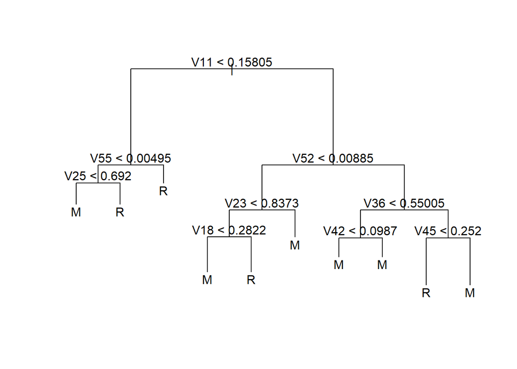

```r
## 5.2: Visualize the decision tree model
plot(model)
text(model)
```

You can see now what the model looks like. V11 is the root node, if V11 is less than 0.15805, then it goes V55, if V11 is greater than that value, it goes to V52. So, you can see how it splits. Let’s continue, if V55 is less than 0.00495, the it goes to V25 which continue to split further.

Let’s proceed and see this another model using rpart() function

```r
## 5.3: Fit the model using the rpart function
model1 <- rpart(Class ~ ., data = Sonar,
           method = "class")
```

This kind of gives us a better representation of the same model that we have. Let’s build the model the same way using the Class variable using all variables as independent variable, the data we will use is the Sonar data, and the method is Class for classification.

```r
## Exercise 5.2: Print the model and the model summary
model1
```

```
## n= 208
##
## node), split, n, loss, yval, (yprob)
##       * denotes terminal node
##
##  1) root 208 97 M (0.5336538 0.4663462)
##    2) V11>=0.19795 121 30 M (0.7520661 0.2479339)
##      4) V16< 0.66655 93 13 M (0.8602151 0.1397849)
##        8) V34< 0.69215 80  6 M (0.9250000 0.0750000) *
##        9) V34>=0.69215 13  6 R (0.4615385 0.5384615) *
##      5) V16>=0.66655 28 11 R (0.3928571 0.6071429)
##       10) V31< 0.3998 15  4 M (0.7333333 0.2666667) *
##       11) V31>=0.3998 13  0 R (0.0000000 1.0000000) *
##    3) V11< 0.19795 87 20 R (0.2298851 0.7701149)
##      6) V4>=0.0515 21  8 M (0.6190476 0.3809524)
##       12) V45>=0.16155 10  0 M (1.0000000 0.0000000) *
##       13) V45< 0.16155 11  3 R (0.2727273 0.7272727) *
##      7) V4< 0.0515 66  7 R (0.1060606 0.8939394) *
```

```r
summary(model1)
```

```
## Call:
## rpart(formula = Class ~ ., data = Sonar, method = "class")
##   n= 208
##
##           CP nsplit rel error    xerror       xstd
## 1 0.48453608      0 1.0000000 1.0000000 0.07417268
## 2 0.06701031      1 0.5154639 0.5773196 0.06594964
## 3 0.05154639      3 0.3814433 0.6494845 0.06832047
## 4 0.01030928      5 0.2783505 0.5670103 0.06557279
## 5 0.01000000      6 0.2680412 0.6288660 0.06768932
##
## Variable importance
## V11 V10  V9 V12 V13  V8 V16  V4 V14 V31 V46 V17 V15 V30 V18 V45 V34 V19 V28 V29
##  12   8   8   8   6   5   4   4   4   3   3   3   3   3   3   2   2   2   2   2
## V47  V3  V5 V37 V33 V52 V21  V2  V6 V27 V35
##   2   1   1   1   1   1   1   1   1   1   1
##
## Node number 1: 208 observations,    complexity param=0.4845361
##   predicted class=M  expected loss=0.4663462  P(node) =1
##     class counts:   111    97
##    probabilities: 0.534 0.466
##   left son=2 (121 obs) right son=3 (87 obs)
##   Primary splits:
##       V11 < 0.19795 to the right, improve=27.60028, (0 missing)
##       V12 < 0.22505 to the right, improve=24.53864, (0 missing)
##       V9  < 0.1164  to the right, improve=20.65490, (0 missing)
##       V10 < 0.16315 to the right, improve=19.89026, (0 missing)
##       V13 < 0.16265 to the right, improve=16.46505, (0 missing)
##   Surrogate splits:
##       V10 < 0.15265 to the right, agree=0.851, adj=0.644, (0 split)
##       V12 < 0.22315 to the right, agree=0.841, adj=0.621, (0 split)
##       V9  < 0.13685 to the right, agree=0.817, adj=0.563, (0 split)
##       V13 < 0.22745 to the right, agree=0.784, adj=0.483, (0 split)
##       V8  < 0.0988  to the right, agree=0.736, adj=0.368, (0 split)
##
## Node number 2: 121 observations,    complexity param=0.06701031
##   predicted class=M  expected loss=0.2479339  P(node) =0.5817308
##     class counts:    91    30
##    probabilities: 0.752 0.248
##   left son=4 (93 obs) right son=5 (28 obs)
```

[output cut: 104 more lines]

```
##
## Node number 11: 13 observations
##   predicted class=R  expected loss=0  P(node) =0.0625
##     class counts:     0    13
##    probabilities: 0.000 1.000
##
## Node number 12: 10 observations
##   predicted class=M  expected loss=0  P(node) =0.04807692
##     class counts:    10     0
##    probabilities: 1.000 0.000
##
## Node number 13: 11 observations
##   predicted class=R  expected loss=0.2727273  P(node) =0.05288462
##     class counts:     3     8
##    probabilities: 0.273 0.727
```

This decision tree model classifies a dataset of 208 observations into classes M and R, with the root node indicating a near-even split (53.37% M and 46.63% R). The first split is based on variable V11 at a threshold of 0.19795. For observations where V11 is greater than or equal to 0.19795 (121 observations), further splits are made on variables V16 and V34, leading to terminal nodes with varying class probabilities. For example, a terminal node where V34 < 0.69215 classifies 80 instances as M with a high probability (92.50%), while another node where V34 >= 0.69215 classifies 13 instances as R (53.85%). Conversely, for observations where V11 is less than 0.19795 (87 observations), additional splits occur on variables V4 and V45, resulting in terminal nodes with distinct class probabilities. For instance, a terminal node where V4 < 0.0515 classifies 66 instances as R with a high probability (89.39%). Terminal nodes, indicated with an asterisk, represent the final classification decisions.

Let’s now visualize the model using the rpart.plot() function. And this gives us a better representation. So let’s run it.

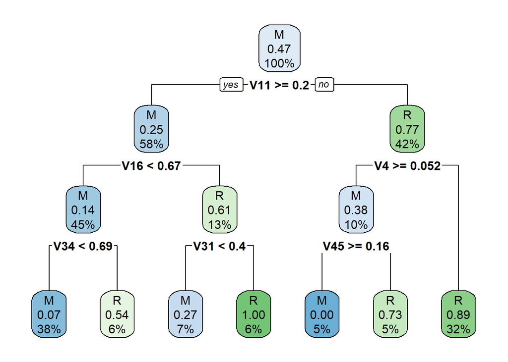

```r
## 5.5: Visualize the new decision tree model
rpart.plot(model1)
```

## Task Six: Evaluating Model Performance

In this task, you will learn how to evaluate the performance of the decision tree model

```r
## 6.1: Make prediction for the first row of the test set
test_set[1, ]
```

```
##       V1     V2     V3     V4     V5    V6     V7     V8     V9    V10    V11
## 3 0.0262 0.0582 0.1099 0.1083 0.0974 0.228 0.2431 0.3771 0.5598 0.6194 0.6333
##     V12    V13   V14    V15    V16    V17    V18    V19    V20    V21    V22
## 3 0.706 0.5544 0.532 0.6479 0.6931 0.6759 0.7551 0.8929 0.8619 0.7974 0.6737
##      V23    V24    V25    V26   V27    V28    V29    V30    V31    V32    V33
## 3 0.4293 0.3648 0.5331 0.2413 0.507 0.8533 0.6036 0.8514 0.8512 0.5045 0.1862
##      V34    V35    V36    V37    V38    V39    V40    V41    V42    V43    V44
## 3 0.2709 0.4232 0.3043 0.6116 0.6756 0.5375 0.4719 0.4647 0.2587 0.2129 0.2222
##      V45    V46    V47    V48   V49    V50    V51    V52    V53    V54   V55
## 3 0.2111 0.0176 0.1348 0.0744 0.013 0.0106 0.0033 0.0232 0.0166 0.0095 0.018
##      V56    V57    V58    V59    V60 Class
## 3 0.0244 0.0316 0.0164 0.0095 0.0078     R
```

```r
predict(model1, newdata = test_set[1, ])
```

```
##   M R
## 3 0 1
```

So this predicts a 1 for R and 0 for M, that means that the first row of the test data is predicted as R. If you would ask me how R do that, is the predict() function has been built in the back-end to run through the decision tree model and checks that the first row is R. The next thing we want to do is to try to make prediction on all of the data.

```r
## 6.2: Making Predictions on the whole test set
prediction <- predict(model1, newdata = test_set, type = "class")
```

We can see our prediction by building a table of predictions. Which is also called the confusion matrix.

```r
## 6.3: Create a table of predictions
table(x = prediction, y =test_set$Class)
```

```
##    y
## x    M  R
##   M 29  3
##   R  4 26
```

Let me first explain what is in confusion matrix before we interpret the result. The upper part value is the actual value, while the right part is the predicted value. The result is saying that there were 29M’s and the model predicted those 29 correctly. That part is called the True Positives. The second column R, first row, is called the False Positives and that means the value actually was R but the model predicted it to be M. So it made three wrong classifications here. Then, in first column second row, our model value is actually M, which is positive but our model predicted it to be R. These are called the False Negatives, it predicted a wrong value, a negative value when actually it was a positive value. The last value which is 26, is saying that our value was R, and the model predicted it correctly to be R. So the values 26 and 29 are the actual positive. The first one is the True positive while the last one is the True negatives. Let’s now move on to evaluating the results using confusionmatrix() function to make evaluation.

```r
## 6.4: Evaluate the prediction results
confusionMatrix(data = prediction,
                reference = test_set$Class)
```

```
## Confusion Matrix and Statistics
##
##           Reference
## Prediction  M  R
##          M 29  3
##          R  4 26
##
##                Accuracy : 0.8871
##                  95% CI : (0.7811, 0.9534)
##     No Information Rate : 0.5323
##     P-Value [Acc > NIR] : 2.418e-09
##
##                   Kappa : 0.7737
##
##  Mcnemar's Test P-Value : 1
##
##             Sensitivity : 0.8788
##             Specificity : 0.8966
##          Pos Pred Value : 0.9062
##          Neg Pred Value : 0.8667
##              Prevalence : 0.5323
##          Detection Rate : 0.4677
##    Detection Prevalence : 0.5161
##       Balanced Accuracy : 0.8877
##
##        'Positive' Class : M
##
```

The upper part is what i already explained a while ago, so lets just proceed to the next part. However, those upper values were used to calculate this accuracy. It shows 0.8871, so about 88%, our model can make good predictions. Of course that’s a good one, but it can also be improved. Next thing to see is the Kappa value of Kappa statistics. It is basically used to control only those instances that may have been correctly classified by chance. So what that means is that the Kappa statistics is frequently used to test reliability of our data. Like are they the correct representations of the variables that we have measured? So, the value 0.6-0.79 like in our case is 0.7737, shows a moderate level of agreement and shows that about 35% to 63% of the data is reliable. And i think that’s enough information. We also have the sensitivity value, which is basically the ability of the test to correctly identify the positive class. In our case it is M. And sensitivity is also called the True Positive Rate. That’s the probability that an actual positive tested to be positive, which is 87.88. In this case, sensitivity is of more interest to us, because we want to try as much as possible to reduce the False Negatives. That is the 4. Let me do an analogy for us to really understand why we are trying to reduce the False Negatives. For example if somebody has diabetes and the prediction model is predicting that the person does not have diabetes. We want to reduce that to the minimum and sensitivity is of interest here. The other part is what we call the specificity, and it is the ability to correctly identify the negative class. So sensitivity is just like the opposite of the specificity. Specificity is also called the True Negative Rate which is the probability that an actual negative will test negative. Then, another one we have is the Positive Prediction Value. This third value which is also called the Precision indicates the rate at which the positive predictions are correct. While sensitivity identifies the rate at which our observation from the positive class are correctly predicted, the Precision indicates the rate at which the positive predictions are correct. Another thins is to calculate the F1 score. The F1 score is usually used the most because its like a bridge between Specificity and Sensitivity and the Precision.

```r
## 6.5: Calculate the F1-Score
## F1 = 2 * (Recall * Precision) / (Recall + Precision)
F1 <- 2 * (0.8788 * 0.9062)/(0.8788 + 0.9062)
F1
```

```
## [1] 0.8922897
```

Our F1 score is 0.8922897 which is quite okay and very interesting. That’s a good value for F1 score. Last thing is to check the prediction error. The misclassification error.

```r
## 6.6: Calculate the prediction error rate
error_rate <- round(mean(prediction != test_set$Class), 2)
error_rate
```

```
## [1] 0.11
```

What this is saying is that, look through the prediction, any where the prediction that we had that does not equate to the class from the test data then find the mean. The error is the actual minus the predicted. We want it to find out and round it to two decimal places. This results to 0.11 which is quite low.

Lasly, lets save the model so we could use it somewhere someday. Maybe we want to build a web apps, or you can we can use it in R shiny someday.

```r
## 6.7: Set Working Directory
getwd()
```

```
## [1] "D:/Desktop/DATA ANALYSIS/PROJECTS/R/DECISION TREE CLASSIFIER IN R"
```

```r
## 6.8: Save the tree model
save(model1, file = "DecisionTree.RData")
```